# Load and Process Data

```r
# set up working directory
setwd("~/Desktop/Coursera/05_ReproducibleResearch/Project01")
getwd()
```

```
## [1] "/Users/SusanMacAir/Desktop/Coursera/05_ReproducibleResearch/Project01"
```

```r
dir()
```

```
## [1] "activity.csv"              "figure"
## [3] "graphics"                  "PA1_template.html"
## [5] "PA1_template.md"           "PA1_template.Rmd"
## [7] "RCode 20150315.R"          "repdata-data-activity.zip"
```

```r
# import raw data
df0_raw <- read.csv("activity.csv")
str(df0_raw)
```

```
## 'data.frame':    17568 obs. of  3 variables:
##  $ steps   : int  NA NA NA NA NA NA NA NA NA NA ...
##  $ date    : Factor w/ 61 levels "2012-10-01","2012-10-02",..: 1 1 1 1 1 1 1 1 1 1 ...
##  $ interval: int  0 5 10 15 20 25 30 35 40 45 ...
```

```r
# convert "date" variable from factor format to date format
df1_date <- data.frame(df0_raw$steps, as.Date(df0_raw$date, "%Y-%m-%d"), df0_raw$interval)
names(df1_date) <- c("steps", "date", "interval")
str(df1_date) # 17568 obs. of  3 variables
```

```
## 'data.frame':    17568 obs. of  3 variables:
##  $ steps   : int  NA NA NA NA NA NA NA NA NA NA ...
##  $ date    : Date, format: "2012-10-01" "2012-10-01" ...
##  $ interval: int  0 5 10 15 20 25 30 35 40 45 ...
```

```r
# load libraries
library(ggplot2)
```

# Find the average number of steps taken per day?

On original data (missing included), agggregate to date level, sum the number of steps

```r
df2_sum_steps_by_date <- aggregate(steps ~ date, data = df1_date, sum)
str(df2_sum_steps_by_date) # 53 obs. of  2 variables
```

```
## 'data.frame':    53 obs. of  2 variables:
##  $ date : Date, format: "2012-10-02" "2012-10-03" ...
##  $ steps: int  126 11352 12116 13294 15420 11015 12811 9900 10304 17382 ...
```

Histogram of sum of number of steps, based on data frame created above

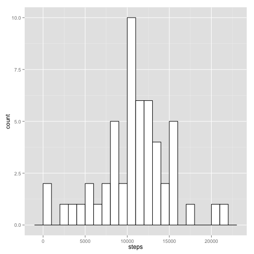

```r
ggplot(df2_sum_steps_by_date, aes(x=steps)) + geom_histogram(binwidth = 1000, colour="black", fill="white")
```

Find mean and median of steps taken per day: Mean = 10770, Median = 10760

```r
summary(df2_sum_steps_by_date$steps)
```

```
##    Min. 1st Qu.  Median    Mean 3rd Qu.    Max.
##      41    8841   10760   10770   13290   21190
```

```r
# Min. 1st Qu.  Median    Mean 3rd Qu.    Max.
# 41    8841   10760   10770   13290   21190
```

# What is the average daily activity pattern?

Calculate the mean number of steps, aggregated by 5-min interval, ignoring missing data

```r
df3_avg_steps_by_interval <- aggregate(steps ~ interval, data = df1_date, mean)
str(df3_avg_steps_by_interval) # 288 obs. of  2 variables
```

```
## 'data.frame':    288 obs. of  2 variables:
##  $ interval: int  0 5 10 15 20 25 30 35 40 45 ...
##  $ steps   : num  1.717 0.3396 0.1321 0.1509 0.0755 ...
```

Plot average number of steps taken as a time series

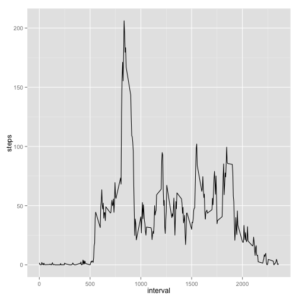

```r
ggplot(df3_avg_steps_by_interval, aes(x = interval, y = steps)) + geom_line()
```

Find 5-min interval with max number of steps

```r
df3_avg_steps_by_interval [df3_avg_steps_by_interval $steps == max(df3_avg_steps_by_interval $steps),]
```

```
##     interval    steps
## 104      835 206.1698
```

```r
# interval 835, at maximum average steps of 206.1698
```